# Ecotoxicology

Marc Los Huertos  
April 19, 2017

### What is Human Health?

Two indicators of Human Health

-Life expectancy: How long people are expected to live?

-Infant mortality: How many children die before age of 1 year?

NOTE: Vary greatly between countries

e.g. Developed versus developing countries

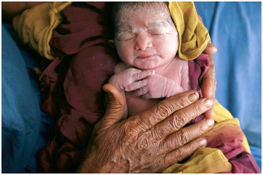

### Health Issues in Developed Countries

- Premature deaths caused by lifestyle
- Poor diet
- Lack of exercise
- Smoking

Obesity is big problem, where we measure “health” using the Body Mass Index:

BMI = Mass (kg)/Height<sup>2</sup> (m) = 740 * (Mass (lb))/ (Height<sup>2</sup> (in))

- < 18.5 is underweight
- 18.5-24.9 is healthy weight
- 25-29 is overweight
- > 30 is obese

### Example of BMI

```r
BMI = 740 * 180/(5*12+11)^2; round(BMI, 1)
```

```
[1] 26.4
```

### BMI Contours

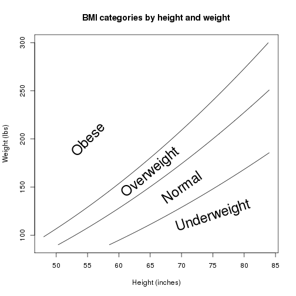

### Regional BMIs

[figure not shown]

### Health Issues in Developing Countries

- Malnutrition, unsafe water, poor sanitation
- Life Expectancy

– Overall is 65 years

– Very poorest developing countries = 45 years

- Most of these countries have high AIDS epidemics

Childhood mortality is high (18% of deaths)

- Diarrheal diseases
- Malnutrition
- Malaria
- AIDS/HIV

### Toxicology

- Toxicology is the study of the effect of toxicants on the human body
- Toxicant- chemical with adverse human health effects

– Acute toxicity: Adverse effects occur within a short period after exposure to toxin

– Chronic toxicity: Adverse effects occur some time after exposure, or after prolonged exposure to toxin Symptoms often mimic other diseases- hard to assess source

### Exposure Studies

Most studies look at one chemical, but humans tend to be exposed to chemical mixtures Ex: automobile exhaust Chemical Mixtures interact by

Additivity

Synergy

Antagonism

These studies are expensive and take a while to complete

### Ecotoxcology

Dilution Paradigm is not valid “Dilution is the solution to pollution” Boomerang Paradigm is accepted “What you throw away can come back and hurt you” Ecotoxicology The study of contaminants in the biosphere and their harmful effects on ecosystems Helps policy makers determine costs and benefits of industrial and technological “advances” And how they often adversely effect ecosystems

### Case Study

Land based nutrient and pollution runoff into ocean is affecting microorganisms

Ex: Red Tide Red pigmented poisonous algal blooms Toxins kill off fish and make humans sick

### Risk Assessment

Risk- probability that a particular adverse effect will result from some exposure or condition We assess risk daily with four steps Hazard identification Dose response assessment Exposure assessment Risk characterization

### Risk Assessment

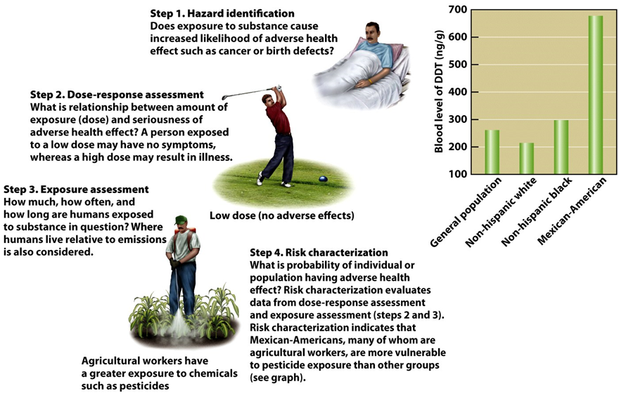

### EPA

[figure not shown]